# 空間分析期中考

地理三陳允杰B10208038

2024-04-08

# 第一題

```r
library(sf)

# 設定工作目錄
setwd("/Users/titan09205030/Desktop/台大修課/空間分析/W4")
# 讀取資料
vill_sf <- st_read("Taipei_Vill.shp", options = "ENCODING=BIG5", quiet = TRUE)
food_sf <- st_read("Tpe_Fastfood.shp", options = "ENCODING=BIG5", quiet = TRUE)

# 篩選出麥當勞速食店
mic_sf <- food_sf[food_sf$STORE == "MIC", ]

# 檢查是否有麥當勞速食店資料
if (nrow(mic_sf) == 0) {
  cat("沒有麥當勞速食店資料。\n")
} else {
  # 初始化向量
  farthest_mcdonalds_distance <- numeric()
  farthest_mcdonalds_store <- character()

  # 計算每個里到最近的麥當勞速食店的距離
  for (i in 1:nrow(vill_sf)) {
    centroid <- st_centroid(vill_sf[i, ])
    distances <- st_distance(mic_sf, centroid, by_element = TRUE)
    max_distance_index <- which.max(distances)
    farthest_mcdonalds_distance[i] <- distances[max_distance_index]
    farthest_mcdonalds_store[i] <- mic_sf$STORE[max_distance_index]
  }

  # 找出距離最遠的里
  farthest_index <- which.max(farthest_mcdonalds_distance)
  farthest_vill_name <- vill_sf$里名稱[farthest_index]
  farthest_vill_district <- vill_sf$行政區[farthest_index]
  farthest_mcdonalds_name <- farthest_mcdonalds_store[farthest_index]
  farthest_distance <- farthest_mcdonalds_distance[farthest_index] / 1000  # 將距離轉換為公里

  # 顯示結果
  cat("距離最遠的里是", farthest_vill_name, "位於", farthest_vill_district, "行政區，最近的麥當勞速食店是", farthest_mcdonalds_name, "，距離為", farthest_distance, "公里。\n")
}
```

[output not shown]

# 第二題

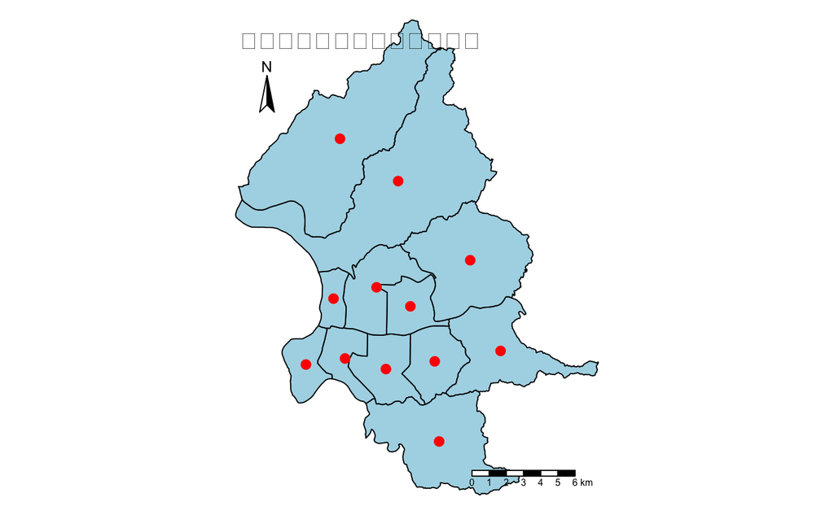

```r
library(sf)
library(dplyr)
library(tmap)
setwd("/Users/titan09205030/Desktop/台大修課/空間分析/W4")
taipei_boundary <- st_read("TPE_TOWN.shp", options = "ENCODING=BIG5", quiet = TRUE)
taipei_vill <- st_read("Taipei_Vill.shp", options = "ENCODING=BIG5", quiet = TRUE)
weighted_center <- taipei_vill %>%
  group_by(TOWN_ID) %>%
  summarise(popu = sum(CENSUS)) %>%
  st_centroid()
vill_map <- tm_shape(taipei_boundary) +
  tm_borders("black") +
  tm_fill("lightblue", title = "台北市各行政區") +
  tm_shape(weighted_center) +
  tm_dots(col = "red", size = 0.3) +
  tm_layout(title = "台北市各行政區加權平均中心",
            legend.outside = TRUE,
            legend.position = c("right", "bottom"),
            legend.bg.color = "white",
            legend.bg.alpha = 0.8,
            frame = FALSE)
vill_map <- vill_map + tm_scale_bar() +
  tm_compass(position = c("left", "top"))
vill_map
```

```r
setwd("/Users/titan09205030/Desktop/台大修課/空間分析/W4")
tpe_fastfood <- st_read("Tpe_Fastfood.shp", options = "ENCODING=BIG5", quiet = TRUE)
closest_mcdonalds <- data.frame(TOWN_ID = character(), Store = character(), Distance = numeric())
for (i in 1:nrow(weighted_center)) {
  center <- weighted_center[i,]
  distances <- st_distance(center, tpe_fastfood)
  closest_index <- which.min(distances)
  closest_store <- tpe_fastfood$STORE[closest_index]
  closest_distance <- min(distances)
  closest_mcdonalds <- rbind(closest_mcdonalds, data.frame(TOWN_ID = weighted_center$TOWN_ID[i], Store = closest_store, Distance = closest_distance))
}
print(closest_mcdonalds)
```

| TOWN_ID | Store | Distance |
| --- | --- | --- |
| 63000010 | MIC | 850.2457 [m] |
| 63000020 | MIC | 556.2250 [m] |
| 63000030 | MIC | 129.0602 [m] |
| 63000040 | MIC | 1102.9731 [m] |
| 63000050 | MIC | 356.8380 [m] |
| 63000060 | MIC | 679.0091 [m] |
| 63000070 | MIC | 265.5541 [m] |
| 63000080 | MIC | 110.2884 [m] |
| 63000090 | MIC | 1920.5249 [m] |
| 63000100 | MIC | 154.0951 [m] |

[output cut: 2 more lines]

```r
NA
```

# 第三題

```r
library(sf)
library(dplyr)
setwd("/Users/titan09205030/Desktop/台大修課/空間分析/W4")
taipei_vill <- st_read("Taipei_Vill.shp", options = "ENCODING=BIG5", quiet = TRUE)
mcdonalds <- st_read("Tpe_Fastfood.shp", options = "ENCODING=BIG5", quiet = TRUE)
buffer_distance <- 2000
mcdonalds_buffer <- st_buffer(mcdonalds, dist = buffer_distance)
# 計算各村里被涵蓋到的麥當勞速食店數量
mcdonalds_coverage <- sapply(st_intersects(mcdonalds_buffer, taipei_vill), function(x) sum(!is.na(x)))
# 找出被最多家麥當勞速食店服務範圍涵蓋的村里
max_coverage <- max(mcdonalds_coverage)
vill_with_max_coverage <- taipei_vill[mcdonalds_coverage == max_coverage, ]
print(vill_with_max_coverage)
```

```
Simple feature collection with 5 features and 8 fields
Geometry type: POLYGON
Dimension:     XY
Bounding box:  xmin: 300319.7 ymin: 2769180 xmax: 312658.6 ymax: 2779258
Projected CRS: TWD97 / TM2 zone 121
    COUNTY_ID VILLAGE_ID VILLAGE COUNTY   TOWN         V_ID  TOWN_ID CENSUS                       geometry
39      63000        001  建民里 臺北市 北投區 63000120-001 63000120   4478 POLYGON ((302185.3 2777722,...
137     63000        017  福住里 臺北市 大安區 63000030-017 63000030   6973 POLYGON ((303754.1 2769605,...
235     63000        009  大有里 臺北市 大同區 63000060-009 63000060   5206 POLYGON ((301606.9 2772335,...
333     63000        003  新富里 臺北市 南港區 63000090-003 63000090   4298 POLYGON ((312653.8 2772005,...
431     63000        017  立農里 臺北市 北投區 63000120-017 63000120   9719 POLYGON ((301647.3 2779044,...
```

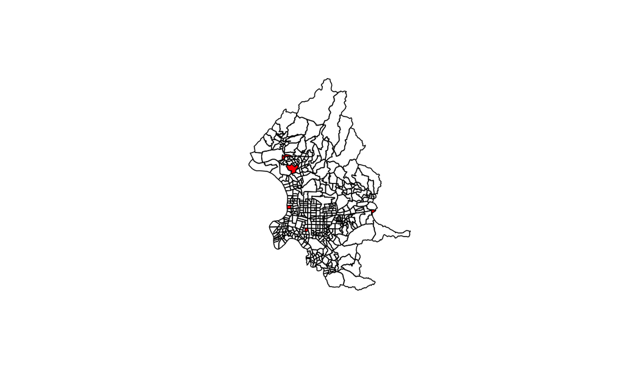

```r
plot(taipei_vill$geometry)
plot(vill_with_max_coverage, add = TRUE, col = "red")
```

# 第四題

```r
library(sf)
library(ggplot2)
library(MASS)

# 設定工作目錄
setwd("/Users/titan09205030/Desktop/台大修課/空間分析/W4")
# 讀取台北市村里資料
taipei_vill <- st_read("Taipei_Vill.shp", options = "ENCODING=BIG5", quiet = TRUE)

# 讀取麥當勞速食店資料
mcdonalds <- st_read("Tpe_Fastfood.shp", options = "ENCODING=BIG5", quiet = TRUE)

# 定義不同帶寬
bandwidths <- c(2000, 5000)  # 2公里和5公里

# 設定網格大小
grid_size <- 300  # 米

# 存儲最大密度和最小密度的里名
max_density_vill <- list()
min_density_vill <- list()

# 創建空的圖形視窗
par(mfrow = c(1, length(bandwidths)))

# 遍歷每個帶寬
for (bw in bandwidths) {
  # 計算核密度估計
  density_est <- kde2d(st_coordinates(mcdonalds)[,1], st_coordinates(mcdonalds)[,2], n = 100, lims = c(min(st_coordinates(mcdonalds)[,1]), max(st_coordinates(mcdonalds)[,1]), min(st_coordinates(mcdonalds)[,2]), max(st_coordinates(mcdonalds)[,2])), h = bw)

  # 將核密度估計轉換為資料框
  density_df <- as.data.frame(density_est)

  # 繪製密度圖
  ggplot(density_df, aes(x = x, y = y, z = z)) +
    geom_tile(aes(fill = z)) +
    scale_fill_gradient(low = "blue", high = "red") +
    ggtitle(paste("Bandwidth:", bw, "m"))
}
```

[output not shown]

```r
# 存儲最大密度和最小密度的網格索引
max_density_index <- list()
min_density_index <- list()

# 遍歷每個帶寬
for (bw in bandwidths) {
  # 計算核密度估計
  density_est <- kde2d(st_coordinates(mcdonalds)[,1], st_coordinates(mcdonalds)[,2], n = 100, lims = c(min(st_coordinates(mcdonalds)[,1]), max(st_coordinates(mcdonalds)[,1]), min(st_coordinates(mcdonalds)[,2]), max(st_coordinates(mcdonalds)[,2])), h = bw)

  # 找到最高密度值對應的網格索引
  max_density_index[[bw]] <- which(density_est$z == max(density_est$z), arr.ind = TRUE)

  # 找到最低密度值對應的網格索引
  min_density_index[[bw]] <- which(density_est$z == min(density_est$z), arr.ind = TRUE)
}

# 將網格索引轉換為里名
for (bw in bandwidths) {
  # 最高密度所在的里
  max_density_coords <- c(density_est$x[max_density_index[[bw]][1]], density_est$y[max_density_index[[bw]][2]])
  max_density_point <- st_point(max_density_coords)
  max_density_point_sf <- st_as_sf(data.frame(x = max_density_coords[1], y = max_density_coords[2]), coords = c("x", "y"))
  max_density_vill <- taipei_vill[st_within(max_density_point_sf, taipei_vill), "VILLAGE"]

  # 最低密度所在的里
  min_density_coords <- c(density_est$x[min_density_index[[bw]][1]], density_est$y[min_density_index[[bw]][2]])
  min_density_point <- st_point(min_density_coords)
  min_density_point_sf <- st_as_sf(data.frame(x = min_density_coords[1], y = min_density_coords[2]), coords = c("x", "y"))
  min_density_vill <- taipei_vill[st_within(min_density_point_sf, taipei_vill), "VILLAGE"]

  # 印出結果
  print(paste("帶寬:", bw, "公尺"))
  print(paste("密度最高的里名:", max_density_vill))
  print(paste("密度最低的里名:", min_density_vill))
}
```

```
Error in st_geos_binop("within", x, y, sparse = sparse, prepared = prepared,  :
  st_crs(x) == st_crs(y) is not TRUE
```

# 第五題

1. 用 90% 的信心水準估計整治前的水質是否達到「嚴重污染河川」？

```r
x_bar <- 113.28
s <- 13.5
n <- 66
t_critical <- qt(0.95, df = n - 1)
margin_of_error <- t_critical * (s / sqrt(n))
confidence_interval <- c(x_bar - margin_of_error, x_bar + margin_of_error)
cat("90% 信心水準下整治前的平均懸浮固體濃度的信心區間:", confidence_interval, "\n")
```

```
90% 信心水準下整治前的平均懸浮固體濃度的信心區間: 110.5072 116.0528
```

```r
if (confidence_interval[1] > 100) {
  cat("整治前的水質達到「嚴重污染河川」的標準。\n")
} else {
  cat("整治前的水質未達到「嚴重污染河川」的標準。\n")
}
```

```
整治前的水質達到「嚴重污染河川」的標準。
```

2. 用 99% 的信心水準評估整治後河川水質的平均懸浮固體濃度，是否有顯著改善？

```r
x_bar_before <- 113.28
x_bar_after <- 98.33
s <- 13.5
n_before <- 66
n_after <- 47
t_value <- (x_bar_before - x_bar_after) / sqrt((s^2 / n_before) + (s^2 / n_after))
t_critical <- qt(0.995, df = n_before + n_after - 2)
cat("t value:", t_value, "\n")
```

```
t value: 5.802152
```

```r
cat("t critical:", t_critical, "\n")
```

```
t critical: 2.620849
```

```r
if (abs(t_value) > t_critical) {
  cat("在99%的信心水準下，整治後的平均懸浮固體濃度與整治前有顯著差異。\n")
} else {
  cat("在99%的信心水準下，整治後的平均懸浮固體濃度與整治前無顯著差異。\n")
}
```

```
在99%的信心水準下，整治後的平均懸浮固體濃度與整治前有顯著差異。
```

應用概念 信賴區間：用於估計母體參數的區間估計方法。在這個問題中，使用了學生 t 分佈的信賴區間，用於估計整治前的水質是否達到「嚴重污染河川」的標準。 https://zh.wikipedia.org/zh-tw/%E4%BF%A1%E8%B3%B4%E5%8D%80%E9%96%93

學生 t 分佈：用於小樣本情況下估計母體平均值的概率分佈。在計算信心區間時，使用了學生 t 分佈的臨界值。 https://homepage.ntu.edu.tw/~clhsieh/biostatistic/5/5-1-2.html

獨立樣本 t 檢定：用於比較兩組樣本均值是否有統計上的顯著差異。在問題(b)中，想要評估整治後河川水質的平均懸浮固體濃度是否有顯著改善，因此使用了獨立樣本 t 檢定。 https://www.yongxi-stat.com/independent-sample-t-test/

統計推論：通過樣本資料對母體參數進行推測和推斷的過程。在這個問題中，透過信心區間和假設檢定進行了統計推論，以評估水質是否達到標準以及水質是否有顯著改善。 https://zh.wikipedia.org/zh-tw/%E6%8E%A8%E8%AB%96%E7%B5%B1%E8%A8%88%E5%AD%B8